# BI PROJECT TRANSCRIPTOME E1A effects

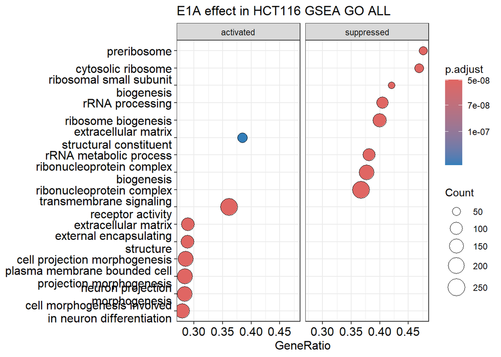

```r
gene_stat_HCT116 <- res_E1A_HCT116$stat
names(gene_stat_HCT116) <- rownames(res_E1A_HCT116)
gene_stat_HCT116 <- na.omit(gene_stat_HCT116)
gene_stat_HCT116 <- sort(gene_stat_HCT116, decreasing = TRUE)

# GSEA GO ALL
go_results <- run_gsea_go(gene_stat_HCT116, title_prefix = "E1A effect in HCT116")
print(go_results$p1)
```

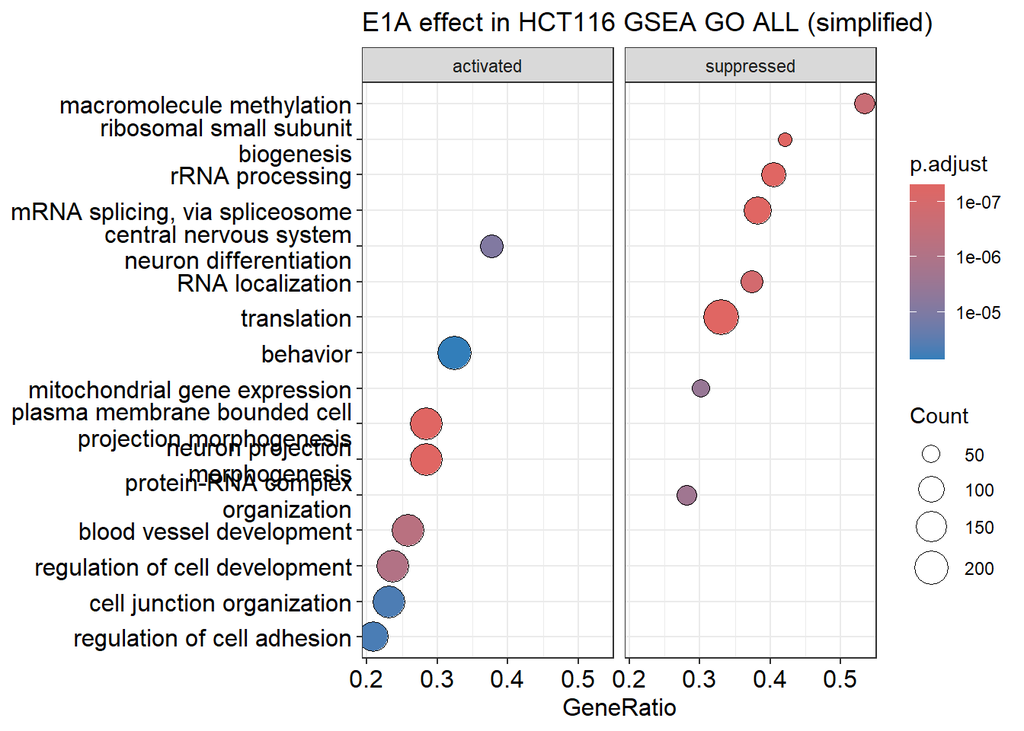

```r
print(go_results$p2)
```

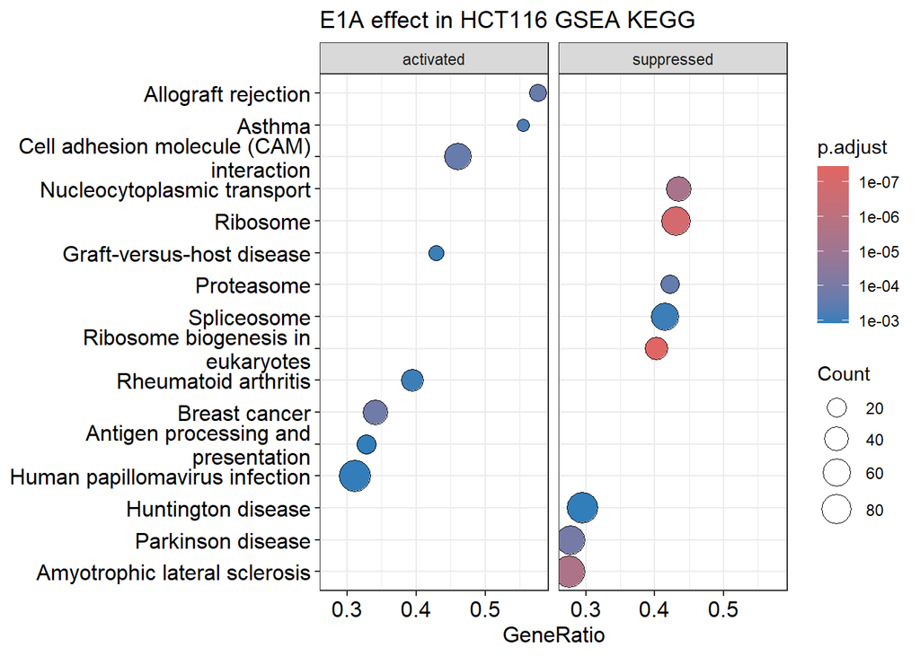

```r
mapping_HCT116 <- mapIds(org.Hs.eg.db,
                         keys = names(gene_stat_HCT116),
                         column = "ENTREZID",
                         keytype = "SYMBOL",
                         multiVals = "first")

gene_list_entrez_HCT116 <- gene_stat_HCT116[!is.na(mapping_HCT116)]
names(gene_list_entrez_HCT116) <- mapping_HCT116[!is.na(mapping_HCT116)]

# KEGG
kegg_results <- run_gsea_kegg(gene_list_entrez_HCT116, title_prefix = "E1A effect in HCT116")
print(kegg_results$plot)
```

When analyzed on 24 samples (the full model, including the resistant line and oxaliplatin treatment), the same pathways (e.g., ribosome biogenesis, extracellular matrix) were also enriched, but had higher p-values (p.adjust ~1e-3 – 1e-5) compared to analysis of HCT116 alone (p.adjust ~5e-08). This indicates that the effect of E1A on the transcriptome is attenuated in the presence of additional factors (oxaliplatin resistance, treatment). In pure HCT116, the effect of E1A is most pronounced and statistically reliable.

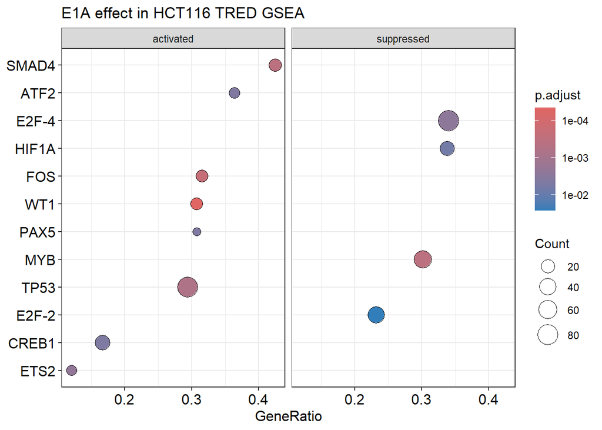

```r
gene_stat_TF <- res_E1A_HCT116$stat
names(gene_stat_TF) <- rownames(res_E1A_HCT116)
gene_stat_TF <- na.omit(gene_stat_TF)
gene_stat_TF <- sort(gene_stat_TF, decreasing = TRUE)

# SYMBOL → ENTREZ
mapping_TF <- mapIds(org.Hs.eg.db,
                     keys = names(gene_stat_TF),
                     column = "ENTREZID",
                     keytype = "SYMBOL",
                     multiVals = "first")

gene_list_entrez_TF <- gene_stat_TF[!is.na(mapping_TF)]
names(gene_list_entrez_TF) <- mapping_TF[!is.na(mapping_TF)]

# TRED GSEA
tred_results <- run_tred_gsea(gene_list_entrez_TF, title_prefix = "E1A effect in HCT116")

print(tred_results$dotplot)
```

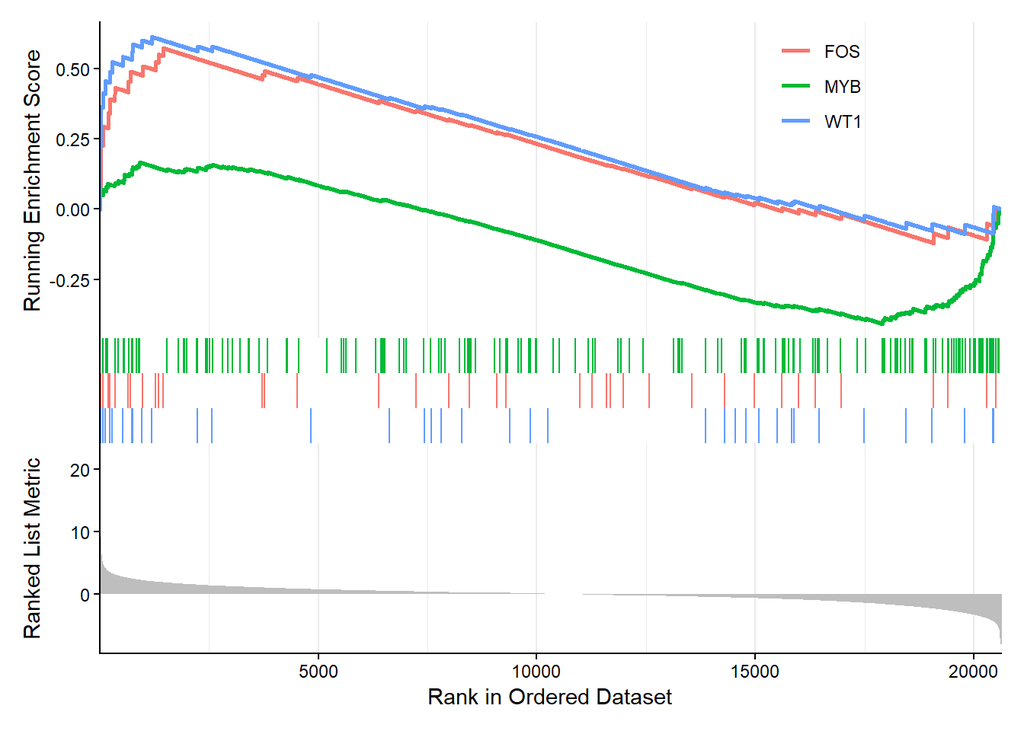

```r
print(tred_results$gseaplot)
```

```r
# Leave only resistant HCT116_oxpl_R cells with control (without oxaliplatin)
keep_R <- colData(dds)$cell_line == "HCT116_oxpl_R" & colData(dds)$condition == "ctrl"
dds_R <- dds[, keep_R]

design(dds_R) <- ~ e1a_status
dds_R <- DESeq(dds_R)

res_E1A_R <- results(dds_R, name = "e1a_status_positive_vs_negative")
summary(res_E1A_R)
```

```
##
## out of 21542 with nonzero total read count
## adjusted p-value < 0.1
## LFC > 0 (up)       : 66, 0.31%
## LFC < 0 (down)     : 24, 0.11%
## outliers [1]       : 26, 0.12%
## low counts [2]     : 3738, 17%
## (mean count < 1)
## [1] see 'cooksCutoff' argument of ?results
## [2] see 'independentFiltering' argument of ?results
```

```r
# up/down |log2FC| > 1
up_R <- sum(res_E1A_R$padj < 0.05 & res_E1A_R$log2FoldChange > 1, na.rm = TRUE)
down_R <- sum(res_E1A_R$padj < 0.05 & res_E1A_R$log2FoldChange < -1, na.rm = TRUE)
cat("Up-regulated:", up_R, "\n")
```

```
## Up-regulated: 43
```

```r
cat("Down-regulated:", down_R, "\n")
```

```
## Down-regulated: 3
```

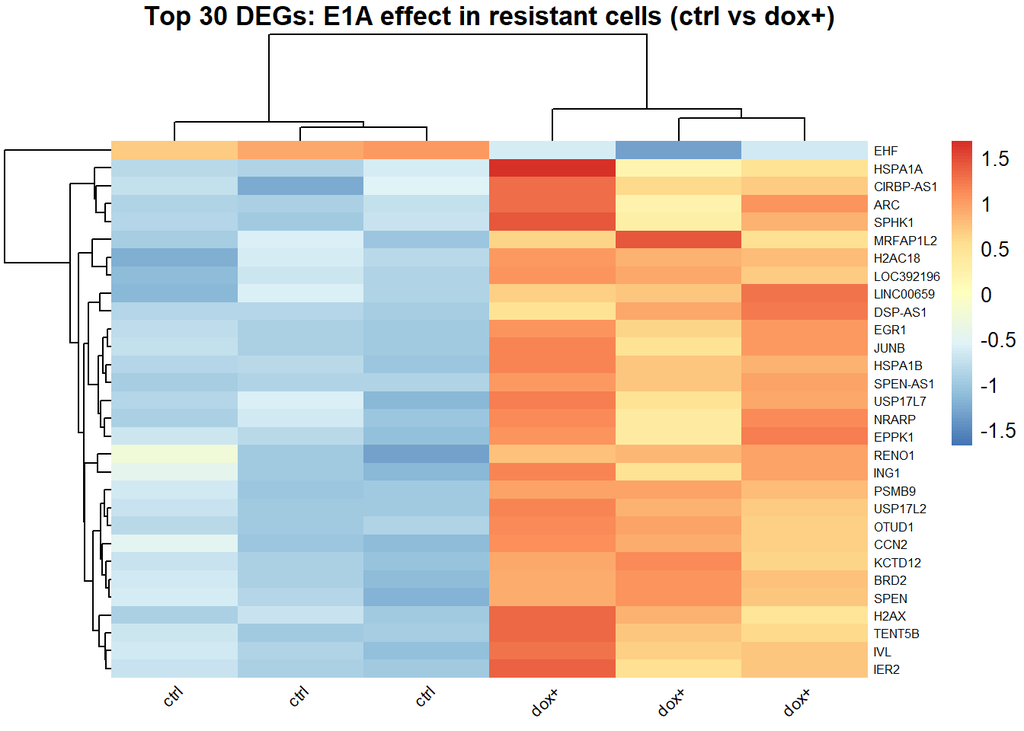

```r
vsd_R <- vst(dds_R, blind = FALSE)

plot_heatmap(
  res = res_E1A_R,
  vsd = vsd_R,
  col_labels = ifelse(colData(dds_R)$e1a_status == "negative", "ctrl", "dox+"),
  n_top = 30,
  title = "Top 30 DEGs: E1A effect in resistant cells (ctrl vs dox+)"
)
```

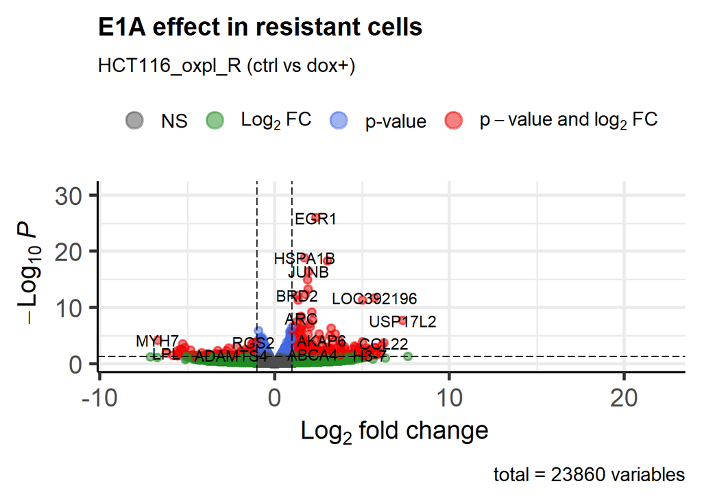

```r
plot_volcano(
  res = res_E1A_R,
  title = "E1A effect in resistant cells",
  subtitle = "HCT116_oxpl_R (ctrl vs dox+)"
)
```

In oxaliplatin-sensitive HCT116 cells, E1A elicits a broader transcriptional response, whereas in resistant HCT116 oxpl-R cells the response is more constrained. TACSTD2 remains mildly induced but to a lower extent in the resistant background, EPHA2 is already highly expressed at baseline in resistant cells, and H2AC18 shows a stronger induction upon doxycycline in the resistant state, suggesting that E1A acts on a pre-rewired chromatin and signaling landscape. Overall, the smaller number of responsive genes in resistant cells indicates reduced transcriptional plasticity to E1A

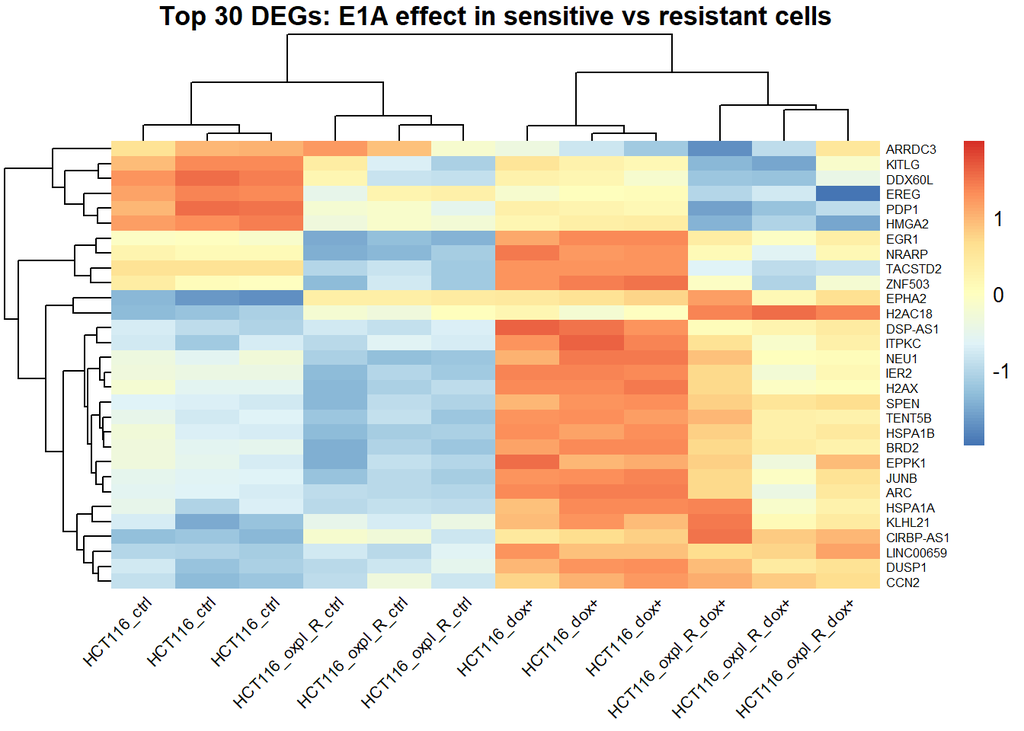

```r
keep_heatmap <- colData(dds)$condition == "ctrl" &
                colData(dds)$cell_line %in% c("HCT116", "HCT116_oxpl_R")

counts_heatmap <- counts(dds)[, keep_heatmap]
coldata_heatmap <- colData(dds)[keep_heatmap, ]

dds_heatmap <- DESeqDataSetFromMatrix(
    countData = counts_heatmap,
    colData = coldata_heatmap,
    design = ~ e1a_status + cell_line
)

vsd_heatmap <- vst(dds_heatmap, blind = FALSE)

col_labels <- paste0(colData(dds_heatmap)$cell_line, "_",
                     ifelse(colData(dds_heatmap)$e1a_status == "negative", "ctrl", "dox+"))

# Heatmap
plot_heatmap(
  res = res_E1A_HCT116,
  vsd = vsd_heatmap,
  col_labels = col_labels,
  n_top = 30,
  title = "Top 30 DEGs: E1A effect in sensitive vs resistant cells"
)
```

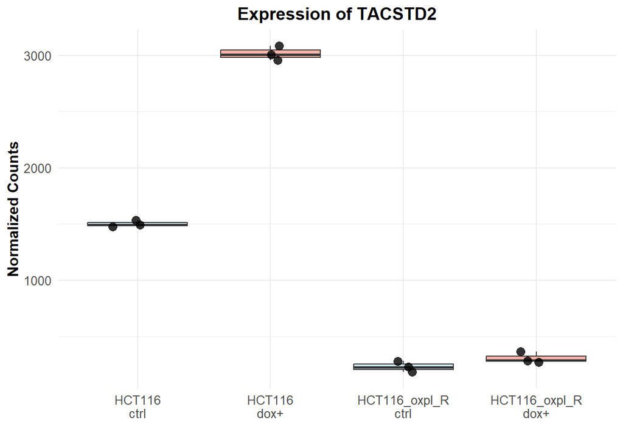

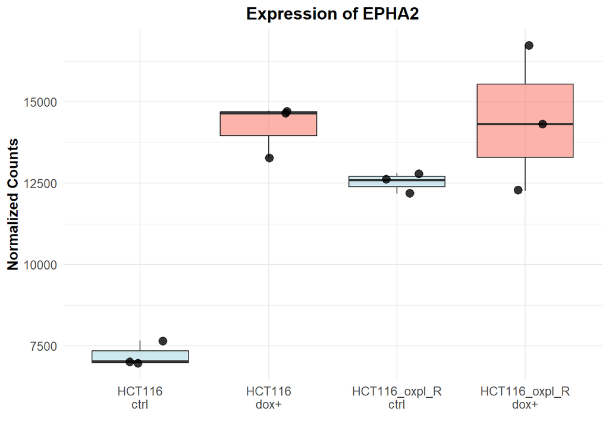

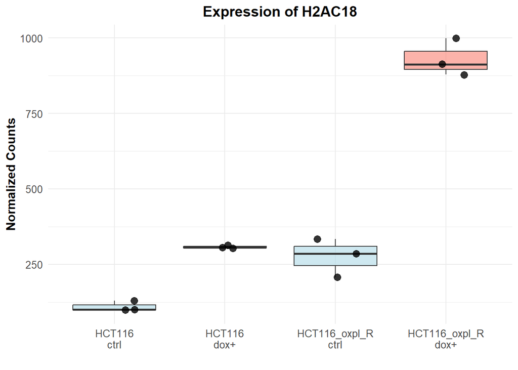

```r
dds_ctrl <- dds[, colData(dds)$condition == "ctrl"]

genes_of_interest <- c("TACSTD2", "EPHA2", "H2AC18")

for (gene in genes_of_interest) {
  ge <- plotCounts(dds_ctrl, gene, intgroup = c("cell_line", "e1a_status"), returnData = TRUE)

  ge$group <- paste0(ge$cell_line, "\n", ifelse(ge$e1a_status == "negative", "ctrl", "dox+"))

  p <- ggplot(ge, aes(x = group, y = count, fill = e1a_status)) +
    geom_boxplot(outlier.shape = NA, alpha = 0.6) +
    geom_jitter(width = 0.2, size = 3, alpha = 0.8) +
    scale_fill_manual(values = c("negative" = "lightblue", "positive" = "salmon")) +
    labs(title = paste("Expression of", gene),
         x = "", y = "Normalized Counts") +
    theme_minimal() +
    theme(legend.position = "none",
          axis.text.x = element_text(size = 10, angle = 0),
          axis.text = element_text(size = 10),
          axis.title = element_text(size = 12, face = "bold"),
          plot.title = element_text(size = 14, face = "bold", hjust = 0.5))

  print(p)
}
```

TACSTD2, EPHA2 and H2AC18 were particularly informative because they reflect different biological layers of the E1A response. TACSTD2 suggests a modest shift in epithelial/cell-surface state, EPHA2 indicates a pre-existing signaling plasticity in oxaliplatin-resistant cells, and H2AC18 points to a strong chromatin-level remodeling response upon doxycycline induction. Together, their behavior suggests that E1A acts on a pre-adapted resistant background rather than on a uniform cellular state.

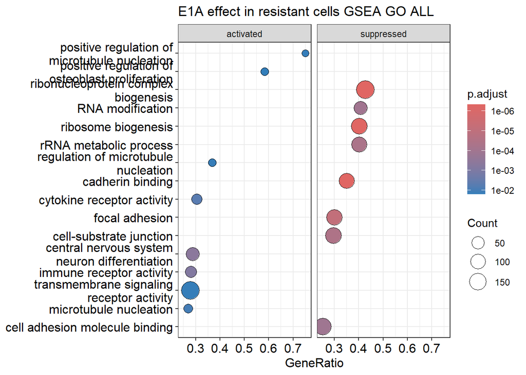

```r
gene_stat_R <- res_E1A_R$stat
names(gene_stat_R) <- rownames(res_E1A_R)
gene_stat_R <- na.omit(gene_stat_R)
gene_stat_R <- sort(gene_stat_R, decreasing = TRUE)

# GSEA GO ALL
go_results <- run_gsea_go(gene_stat_R, title_prefix = "E1A effect in resistant cells")
print(go_results$p1)
```

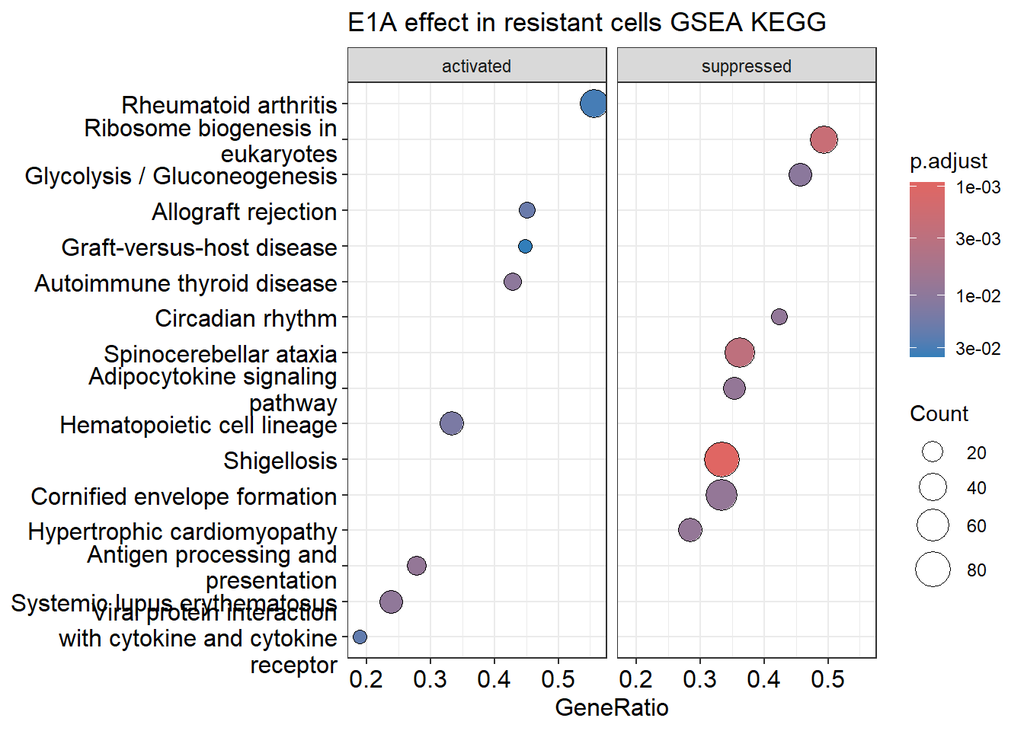

```r
gene_stat_R <- res_E1A_R$stat
names(gene_stat_R) <- rownames(res_E1A_R)
gene_stat_R <- na.omit(gene_stat_R)
gene_stat_R <- sort(gene_stat_R, decreasing = TRUE)

# SYMBOL → ENTREZ
mapping_R <- mapIds(org.Hs.eg.db,
                    keys = names(gene_stat_R),
                    column = "ENTREZID",
                    keytype = "SYMBOL",
                    multiVals = "first")

gene_list_entrez_R <- gene_stat_R
names(gene_list_entrez_R) <- mapping_R
gene_list_entrez_R <- na.omit(gene_list_entrez_R)

# KEGG
kegg_results <- run_gsea_kegg(gene_list_entrez_R, title_prefix = "E1A effect in resistant cells")
print(kegg_results$plot)
```